# Project 2

My dataset is the [Break Free From Plastic (BFFP)](https://github.com/rfordatascience/tidytuesday/blob/main/data/2021/2021-01-26/readme.mdz) from TidyTuesdays. This dataset looks at plastic waste collected during cleanup events around the world, where volunteers record variables like the country, year, parent company responsible, and counts of different plastic types.

The data comes from Break Free From Plastic global brand audits, which are organized to better understand where plastic pollution is coming from and to hold companies accountable. The dataset I’m using was put together by Sarah Sauve, who combined data from the 2019 and 2020 audits into one dataset. You find it [here](https://github.com/sarahsauve/TidyTuesdays/blob/master/BFFPDashboard/BlogPost.md).

She also created a blog post and a Shiny app describing her data cleaning process and analysis. She made it to contribute to global audit, and as a way to understand plastic waste in St. John.

Each observation represents a summary of plastic collected for a specific company, in a specific country, and year. The values in each row are counts of different types of plastic for each company.

The data was collected to better understand where plastic pollution is coming from and to help hold companies accountable for their plastic waste. We are interested in it because it allows us to identify which companies and countries contribute the most to plastic pollution, and to examine how the composition of plastic types varies across countries and over time.

**Variables:**

- **country:** where the brand audit was conducted
- **year:** year of the audit, 2019 or 2020
- **parent company:** The company whose plastic waste was counted. “Unbranded” represents plastic without a known or identifiable brand.
- **empty:** number of unlabeled pieces of plastic
- **hdpe:** number of High-Density Polyethylene pieces
- **ldpe:** number of Low-Density Polyethylene pieces
- **o:** number of “other” types of plastic pieces that don’t fall into the other categories
- **pet:** number of Polyethylene Terephthalate pieces
- **pp:** number of Polypropylene pieces
- **ps:** number of Polystyrene pieces
- **pvc:** number of Polyvinyl Chloride pieces
- **grand total:** the total count of plastic pieces across all types for that country/brand/year audit
- **num_events:** the number of clean-up events held
- **volunteers:** the number of volunteers who participated in the audit

jonthegeek used janitor to clean the data. He…

- used janitor::clean_names() to standardize the column names without changing them manually,
- converted grand_total into a character to deal with the commas that were included in the numbers and then removed the commas,
- used set_names() and map_dfr() to with the .id argument to create the country column,
- dropped duplicate pp and ps columns using select(), and
- added a year column using rbind() to combine the 2019 and 2020 data into one data set.

```
# A tibble: 6 × 14
  country    year parent_company empty  hdpe  ldpe     o   pet    pp    ps   pvc
  <chr>     <dbl> <chr>          <dbl> <dbl> <dbl> <dbl> <dbl> <dbl> <dbl> <dbl>
1 Argentina  2019 Grand Total        0   215    55   607  1376   281   116    18
2 Argentina  2019 Unbranded          0   155    50   532   848   122   114    17
3 Argentina  2019 The Coca-Cola…     0     0     0     0   222    35     0     0
4 Argentina  2019 Secco              0     0     0     0    39     4     0     0
5 Argentina  2019 Doble Cola         0     0     0     0    38     0     0     0
6 Argentina  2019 Pritty             0     0     0     0    22     7     0     0
# ℹ 3 more variables: grand_total <dbl>, num_events <dbl>, volunteers <dbl>
```

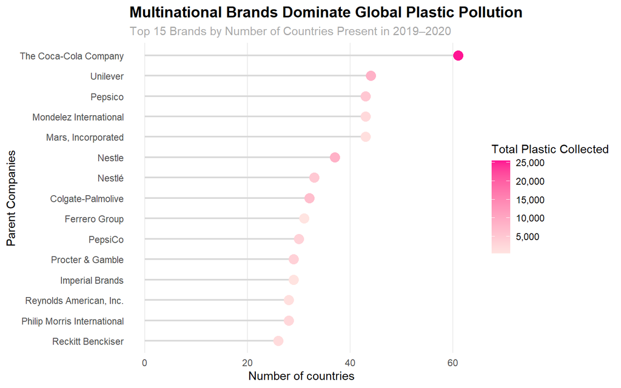

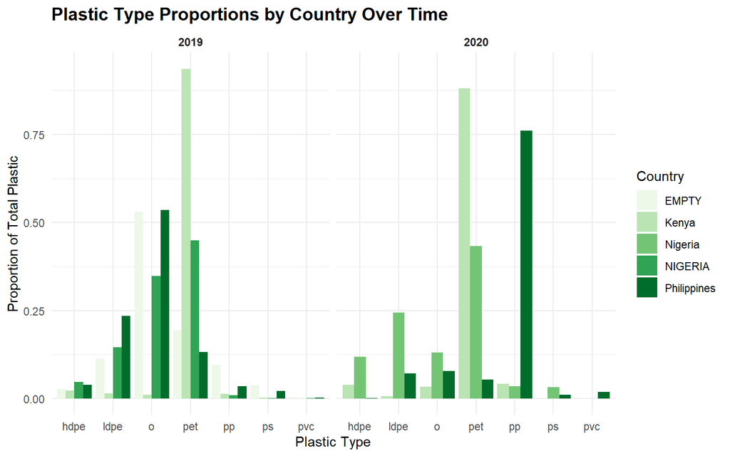

**Pollution Scores by Company**

This summary table shows which companies have the highest plastic pollution score based on recycling difficulty, and I want to see if they overlap with the brands most present across countries. I came up with these weights through an article from the US Department of Energy https://www.energy.gov/sites/default/files/2021-12/ES_ConsumerGuide_RecyclingCodes.pdf

Table 1: shows which companies have the highest plastic pollution score based on recycling difficulty

Plastic Pollution Scores by Company

Top 10 companies ranked by weighted recycling difficulty score

| Company | Total Score | Total Plastic | Avg Score Per Piece |
| --- | --- | --- | --- |
| Universal Robina Corporation | 39,708 | 8,651 | 4.59 |
| Nestle | 38,592 | 8,642 | 4.47 |
| Unilever | 37,854 | 8,589 | 4.41 |
| The Coca-Cola Company | 34,010 | 25,530 | 1.33 |
| Colgate-Palmolive | 31,329 | 6,545 | 4.79 |
| La Doo | 15,221 | 15,221 | 1.00 |
| Pepsico | 11,142 | 5,155 | 2.16 |
| Barna | 6,225 | 6,225 | 1.00 |
| Pure Water, Inc. | 2,285 | 5,347 | 0.43 |
| Assorted | 0 | 6,101 | 0.00 |

Source: Break Free From Plastic brand audit data (2019-2020). Weights based on recycling rates: PET(1), HDPE(2), PVC(3), Other(4), PP(5), PS(6), LDPE(7) from the US Department of Energy

**Plastic Types by Country & Year**

Here, I wanted see how the proportion of different plastic types differ across countries and changed over time.

Table 2: shows the proportion of each plastic type collected per country for both 2019 and 2020

Proportion of Plastic Types by Country and Year

Each value represents the share of total plastic for that type

| Country | 2019 HDPE | 2019 LDPE | 2019 Other | 2019 PET | 2019 PP | 2019 PS | 2019 PVC | 2019 Total Plastic | 2020 HDPE | 2020 LDPE | 2020 Other | 2020 PET | 2020 PP | 2020 PS | 2020 PVC | 2020 Total Plastic |
| --- | --- | --- | --- | --- | --- | --- | --- | --- | --- | --- | --- | --- | --- | --- | --- | --- |
| Argentina | 0.08 | 0.02 | 0.23 | 0.52 | 0.10 | 0.04 | 0.01 | 5,336.00 | 0.12 | 0.13 | 0.20 | 0.13 | 0.24 | 0.06 | 0.00 | 1,086.00 |
| Australia | 0.00 | 0.00 | 0.00 | 1.00 | 0.00 | 0.00 | 0.00 | 6.00 | 0.02 | 0.13 | 0.54 | 0.08 | 0.22 | 0.00 | 0.00 | 1,668.00 |
| Bangladesh | 0.00 | 0.00 | 1.00 | 0.00 | 0.00 | 0.00 | 0.00 | 32.00 | 0.16 | 0.00 | 0.65 | 0.12 | 0.04 | 0.02 | 0.00 | 2,383.00 |
| Benin | 0.00 | 0.00 | 0.00 | 1.00 | 0.00 | 0.00 | 0.00 | 9,976.00 | 0.00 | 0.00 | 0.00 | 1.00 | 0.00 | 0.00 | 0.00 | 342.00 |
| Brazil | 0.01 | 0.00 | 0.76 | 0.05 | 0.19 | 0.00 | 0.00 | 9,468.00 | 0.05 | 0.25 | 0.17 | 0.18 | 0.24 | 0.09 | 0.01 | 2,257.00 |
| Bulgaria | 0.00 | 0.00 | 0.00 | 1.00 | 0.00 | 0.00 | 0.00 | 16.00 | 0.02 | 0.07 | 0.26 | 0.15 | 0.41 | 0.03 | 0.03 | 480.00 |
| Burkina Faso | 0.00 | 0.36 | 0.05 | 0.56 | 0.02 | 0.01 | 0.00 | 11,636.00 | 0.03 | 0.00 | 0.41 | 0.53 | 0.01 | 0.01 | 0.00 | 8,774.00 |
| Canada | 0.00 | 0.00 | 1.00 | 0.00 | 0.00 | 0.00 | 0.00 | 2.00 | 0.06 | 0.32 | 0.23 | 0.15 | 0.15 | 0.08 | 0.00 | 1,887.00 |
| China | 0.00 | 0.00 | 0.66 | 0.34 | 0.00 | 0.00 | 0.00 | 6,918.00 | 0.00 | 0.00 | 0.94 | 0.05 | 0.00 | 0.00 | 0.00 | 2,332.00 |
| Colombia | 0.00 | 0.00 | 1.00 | 0.00 | 0.00 | 0.00 | 0.00 | 1,712.00 | 0.06 | 0.07 | 0.26 | 0.57 | 0.04 | 0.00 | 0.00 | 6,215.00 |

Source: Break Free From Plastic brand audit data (2019-2020)

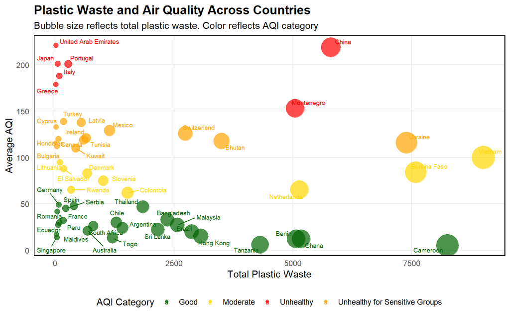

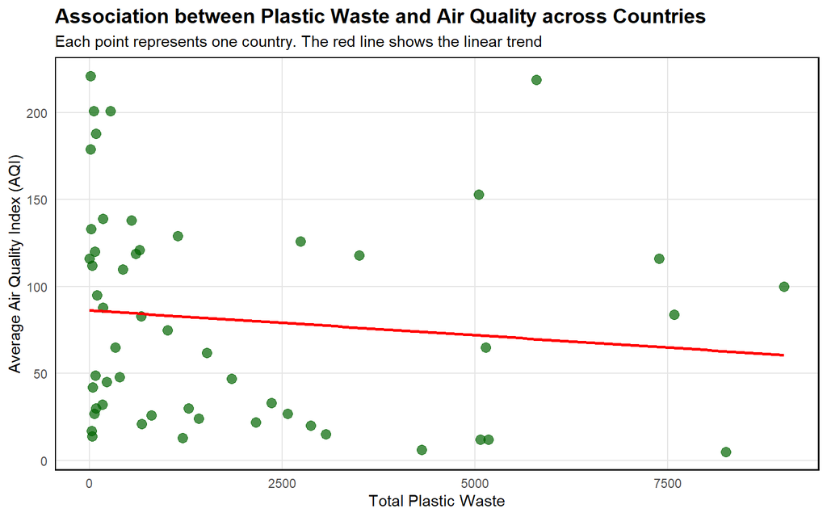

**Top 10 Countries**

```
# A tibble: 10 × 4
   country      total_plastic total_volunteers avg_aqi
   <chr>                <dbl>            <dbl>   <dbl>
 1 Philippines          58094          2767429     195
 2 Nigeria              21834           698967      22
 3 Kenya                14522           184128      24
 4 India                14478           140354     129
 5 Indonesia            12843          4457364      42
 6 Vietnam               9007           273802     100
 7 Cameroon              8253            58050       5
 8 Burkina Faso          7583             8229      84
 9 Ukraine               7383           126042     116
10 China                 5791          1363419     219
```

**AQI by Plastic Level**

Table 3: groups countries into four quartiles based on their total plastic waste, from lowest (Q1) to highest (Q4)

Air Quality by Plastic Waste Level

Countries grouped into quartiles by total plastic waste

[output not shown]

Note: Higher AQI indicates worse air quality. Countries filtered to remove outliers.

**Best vs Worst Air Quality**

Table 4: compares the 5 countries with the best air quality against the 5 countries with the worst air quality

Best vs Worst Air Quality Countries

Do countries with the worst air quality also have the most plastic waste?

| Country | Average AQI | Total Plastic Waste |
| --- | --- | --- |
| Worst Air Quality |  |  |
| United Arab Emirates | 221.00 | 12.00 |
| China | 219.00 | 5,791.00 |
| Portugal | 201.00 | 272.00 |
| Japan | 201.00 | 53.00 |
| Italy | 188.00 | 82.00 |
| Best Air Quality |  |  |
| Cameroon | 5.00 | 8,253.00 |
| Tanzania | 6.00 | 4,308.00 |
| Ghana | 12.00 | 5,169.00 |
| Benin | 12.00 | 5,066.00 |
| Togo | 13.00 | 1,209.00 |

Note: Top and bottom 5 countries ranked by average AQI across 2019-2020.

**Model Results**

Table 5: table shows the results of a linear regression model predicting average AQI from total plastic waste across countries

Linear Regression Results

Predicting Average AQI from Total Plastic Waste by Country

| Term | Coefficient Information Estimate | Coefficient Information Standard Error | Test Statistics T-Statistic | Test Statistics P-Value |
| --- | --- | --- | --- | --- |
| Intercept | 77.593 | 8.957 | 8.662 | 0.0000 |
| Total Plastic | 0.001 | 0.001 | 0.957 | 0.3429 |

R² = 0.0161 | Adjusted R² = -0.0015 | F-statistic = 0.915 | Model p-value = 0.3429